# Table Output

4/16/2020

#### *Number of observed points in BLM range yearly*

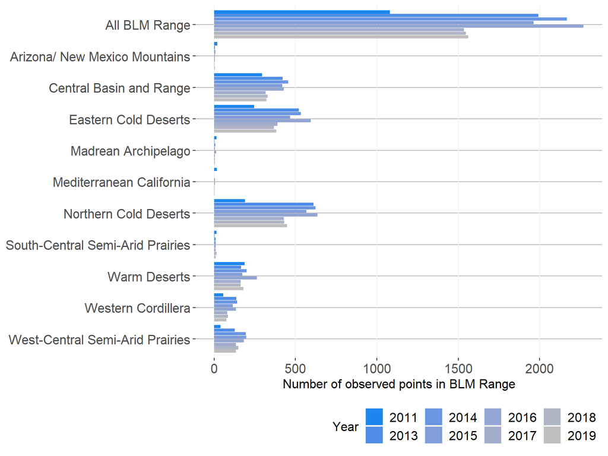

#### *Proportion of BLM rangelands with none-to-slight or slight-to-moderate departure from biotic integrity reference conditions (BI <=2) (80% confidence interval)*

| Ecoregion | 2011* | 2013 | 2014 | 2015 | 2016 | 2017 | 2018 | 2019 |
| --- | --- | --- | --- | --- | --- | --- | --- | --- |
| Proportion of BLM rangelands with none-to-slight or slight-to-moderate departure from biotic integrity reference conditions (BI <=2) (80% confidence interval) |  |  |  |  |  |  |  |  |
| All BLM Range | 89% (+1/-1) | 83% (+2/-2) | 85% (+2/-2) | 85% (+2/-2) | 85% (+1/-1) | 86% (+2/-2) | 88% (+1/-1) | 94% (+2/-2) |
| Arizona/ New Mexico Mountains | 47% (+33/-33) | NA | NA | NA | NA | NA | NA | NA |
| Central Basin and Range | 95% (+3/-3) | 88% (+3/-3) | 84% (+3/-3) | 83% (+3/-3) | 95% (+2/-2) | 93% (+2/-2) | 97% (+2/-2) | 99% (+1/-1) |
| Eastern Cold Deserts | 89% (+3/-3) | 75% (+7/-7) | 86% (+3/-3) | 80% (+4/-4) | 83% (+3/-3) | 87% (+4/-4) | 93% (+2/-2) | 96% (+2/-2) |
| Madrean Archipelago | 84% (+15/-15) | NA | NA | NA | 76% (+24/-32) | NA | NA | NA |
| Mediterranean California | 100% (+0/-0) | NA | NA | NA | NA | NA | NA | NA |
| Northern Cold Deserts | 83% (+6/-6) | 87% (+3/-3) | 93% (+2/-2) | 89% (+3/-3) | 82% (+2/-2) | 84% (+3/-3) | 84% (+3/-3) | 96% (+1/-1) |
| South-Central Semi-Arid Prairies | 89% (+11/-16) | NA | 9% (+13/-9) | 80% (+17/-17) | 80% (+20/-28) | NA | 79% (+20/-20) | NA |
| Warm Deserts | 78% (+7/-7) | 80% (+8/-8) | 75% (+4/-4) | 80% (+6/-6) | 67% (+6/-6) | 67% (+9/-9) | 70% (+9/-9) | 79% (+7/-7) |
| West-Central Semi-Arid Prairies | 96% (+4/-5) | 97% (+2/-2) | 93% (+5/-5) | 96% (+4/-4) | 95% (+3/-3) | 96% (+2/-2) | 94% (+4/-4) | 98% (+1/-1) |
| Western Cordillera | 95% (+4/-4) | 84% (+12/-12) | 86% (+9/-9) | 93% (+5/-5) | 88% (+7/-7) | 88% (+9/-9) | 91% (+5/-5) | 92% (+7/-7) |

* NA: Estimates unavailable due to small sample size (fewer than 10 plots)

#### *Proportion of BLM rangelands with moderate departure from biotic integrity reference conditions (BI = 3) (80% confidence interval)*

| Ecoregion | 2011* | 2013 | 2014 | 2015 | 2016 | 2017 | 2018 | 2019 |
| --- | --- | --- | --- | --- | --- | --- | --- | --- |
| Proportion of BLM rangelands with moderate departure from biotic integrity reference conditions (BI = 3) (80% confidence interval) |  |  |  |  |  |  |  |  |
| All BLM Range | 8% (+1/-1) | 12% (+2/-2) | 11% (+1/-1) | 11% (+1/-1) | 10% (+1/-1) | 11% (+1/-1) | 8% (+1/-1) | 4% (+1/-1) |
| Arizona/ New Mexico Mountains | 36% (+16/-16) | NA | NA | NA | NA | NA | NA | NA |
| Central Basin and Range | 5% (+3/-3) | 8% (+3/-3) | 12% (+3/-3) | 11% (+2/-2) | 5% (+2/-2) | 7% (+2/-2) | 3% (+1/-1) | 1% (+1/-1) |
| Eastern Cold Deserts | 9% (+3/-3) | 20% (+7/-7) | 11% (+3/-3) | 14% (+3/-3) | 10% (+2/-2) | 10% (+3/-3) | 5% (+2/-2) | 2% (+1/-1) |
| Madrean Archipelago | 16% (+15/-15) | NA | NA | NA | 0% (+0/-0) | NA | NA | NA |
| Mediterranean California | 0% (+0/-0) | NA | NA | NA | NA | NA | NA | NA |
| Northern Cold Deserts | 13% (+5/-5) | 9% (+2/-2) | 6% (+2/-2) | 10% (+3/-3) | 14% (+2/-2) | 14% (+3/-3) | 14% (+3/-3) | 3% (+1/-1) |
| South-Central Semi-Arid Prairies | 11% (+16/-11) | NA | 50% (+21/-21) | 20% (+17/-17) | 20% (+28/-20) | NA | 21% (+20/-20) | NA |
| Warm Deserts | 7% (+4/-4) | 9% (+5/-5) | 12% (+5/-5) | 10% (+4/-4) | 17% (+5/-5) | 18% (+7/-7) | 13% (+6/-6) | 11% (+5/-5) |
| West-Central Semi-Arid Prairies | 4% (+5/-4) | 3% (+2/-2) | 7% (+5/-5) | 3% (+4/-3) | 5% (+3/-3) | 4% (+2/-2) | 3% (+2/-2) | 2% (+1/-1) |
| Western Cordillera | 5% (+4/-4) | 16% (+12/-12) | 8% (+4/-4) | 7% (+4/-4) | 8% (+5/-5) | 9% (+9/-9) | 9% (+5/-5) | 8% (+7/-7) |

* NA: Estimates unavailable due to small sample size (fewer than 10 plots)

#### *Proportion of BLM rangelands with moderate or moderate-to-extreme or extreme-to-total departure from biotic integrity reference conditions (BI >=3) (80% confidence interval)*

| Ecoregion | 2011* | 2013 | 2014 | 2015 | 2016 | 2017 | 2018 | 2019 |
| --- | --- | --- | --- | --- | --- | --- | --- | --- |
| Proportion of BLM rangelands with moderate or moderate-to-extreme or extreme-to-total departure from biotic integrity reference conditions (BI >=3) (80% confidence interval) |  |  |  |  |  |  |  |  |
| All BLM Range | 11% (+1/-1) | 17% (+2/-2) | 15% (+2/-2) | 15% (+2/-2) | 15% (+1/-1) | 14% (+2/-2) | 12% (+1/-1) | 6% (+2/-2) |
| Arizona/ New Mexico Mountains | 53% (+33/-33) | NA | NA | NA | NA | NA | NA | NA |
| Central Basin and Range | 5% (+3/-3) | 12% (+3/-3) | 16% (+3/-3) | 17% (+3/-3) | 5% (+2/-2) | 7% (+2/-2) | 3% (+2/-2) | 1% (+1/-1) |
| Eastern Cold Deserts | 11% (+3/-3) | 25% (+7/-7) | 14% (+3/-3) | 20% (+4/-4) | 17% (+3/-3) | 13% (+4/-4) | 7% (+2/-2) | 4% (+2/-2) |
| Madrean Archipelago | 16% (+15/-15) | NA | NA | NA | 24% (+32/-24) | NA | NA | NA |
| Mediterranean California | 0% (+0/-0) | NA | NA | NA | NA | NA | NA | NA |
| Northern Cold Deserts | 17% (+6/-6) | 13% (+3/-3) | 7% (+2/-2) | 11% (+3/-3) | 18% (+2/-2) | 16% (+3/-3) | 16% (+3/-3) | 4% (+1/-1) |
| South-Central Semi-Arid Prairies | 11% (+16/-11) | NA | 91% (+9/-13) | 20% (+17/-17) | 20% (+28/-20) | NA | 21% (+20/-20) | NA |
| Warm Deserts | 22% (+7/-7) | 20% (+8/-8) | 25% (+4/-4) | 20% (+6/-6) | 33% (+6/-6) | 33% (+9/-9) | 30% (+9/-9) | 21% (+7/-7) |
| West-Central Semi-Arid Prairies | 4% (+5/-4) | 3% (+2/-2) | 7% (+5/-5) | 4% (+4/-4) | 5% (+3/-3) | 4% (+2/-2) | 6% (+4/-4) | 2% (+1/-1) |
| Western Cordillera | 5% (+4/-4) | 16% (+12/-12) | 14% (+9/-9) | 7% (+5/-5) | 12% (+7/-7) | 12% (+9/-9) | 9% (+5/-5) | 8% (+7/-7) |

* NA: Estimates unavailable due to small sample size (fewer than 10 plots)

#### *Proportion of BLM rangelands with moderate-to-extreme or extreme-to-total departure from biotic integrity reference conditions (BI >= 4) (80% confidence interval)*

| Ecoregion | 2011* | 2013 | 2014 | 2015 | 2016 | 2017 | 2018 | 2019 |
| --- | --- | --- | --- | --- | --- | --- | --- | --- |
| Proportion of BLM rangelands with moderate-to-extreme or extreme-to-total departure from biotic integrity reference conditions (BI >= 4) (80% confidence interval) |  |  |  |  |  |  |  |  |
| All BLM Range | 3% (+1/-1) | 5% (+1/-1) | 5% (+1/-1) | 5% (+1/-1) | 5% (+1/-1) | 3% (+1/-1) | 4% (+1/-1) | 2% (+1/-1) |
| Arizona/ New Mexico Mountains | 17% (+25/-17) | NA | NA | NA | NA | NA | NA | NA |
| Central Basin and Range | 0% (+0/-0) | 3% (+2/-2) | 4% (+1/-1) | 6% (+2/-2) | 0% (+0/-0) | 0% (+0/-0) | 0% (+1/-0) | 0% (+0/-0) |
| Eastern Cold Deserts | 2% (+1/-1) | 5% (+2/-2) | 3% (+1/-1) | 6% (+2/-2) | 7% (+2/-2) | 3% (+2/-2) | 2% (+1/-1) | 2% (+2/-2) |
| Madrean Archipelago | 0% (+0/-0) | NA | NA | NA | 24% (+32/-24) | NA | NA | NA |
| Mediterranean California | 0% (+0/-0) | NA | NA | NA | NA | NA | NA | NA |
| Northern Cold Deserts | 3% (+3/-3) | 4% (+2/-2) | 1% (+1/-1) | 1% (+1/-1) | 3% (+2/-2) | 2% (+1/-1) | 2% (+1/-1) | 0% (+0/-0) |
| South-Central Semi-Arid Prairies | 0% (+0/-0) | NA | 41% (+25/-25) | 0% (+0/-0) | 0% (+0/-0) | NA | 0% (+0/-0) | NA |
| Warm Deserts | 16% (+6/-6) | 11% (+6/-6) | 14% (+5/-5) | 10% (+4/-4) | 16% (+5/-5) | 15% (+7/-7) | 17% (+7/-7) | 9% (+6/-6) |
| West-Central Semi-Arid Prairies | 0% (+0/-0) | 0% (+0/-0) | 0% (+0/-0) | 0% (+0/-0) | 0% (+1/-0) | 0% (+0/-0) | 2% (+3/-2) | 0% (+0/-0) |
| Western Cordillera | 0% (+0/-0) | 0% (+0/-0) | 6% (+8/-6) | 1% (+1/-1) | 4% (+5/-4) | 3% (+4/-3) | 0% (+0/-0) | 0% (+0/-0) |

* NA: Estimates unavailable due to small sample size (fewer than 10 plots)

#### *Proportion of BLM rangelands with none-to-slight or slight-to-moderate departure from hydrologic function reference conditions (HF <=2) (80% confidence interval)*

| Ecoregion | 2011* | 2013 | 2014 | 2015 | 2016 | 2017 | 2018 | 2019 |
| --- | --- | --- | --- | --- | --- | --- | --- | --- |
| Proportion of BLM rangelands with none-to-slight or slight-to-moderate departure from hydrologic function reference conditions (HF <=2) (80% confidence interval) |  |  |  |  |  |  |  |  |
| All BLM Range | 90% (+1/-1) | 85% (+2/-2) | 90% (+1/-1) | 90% (+1/-1) | 90% (+1/-1) | 93% (+2/-1) | 92% (+1/-1) | 94% (+1/-1) |
| Arizona/ New Mexico Mountains | 65% (+35/-50) | NA | NA | NA | NA | NA | NA | NA |
| Central Basin and Range | 97% (+2/-2) | 94% (+2/-2) | 91% (+2/-2) | 88% (+2/-2) | 97% (+1/-1) | 98% (+1/-1) | 97% (+2/-2) | 100% (+0/-1) |
| Eastern Cold Deserts | 87% (+3/-3) | 75% (+5/-5) | 86% (+4/-4) | 81% (+5/-5) | 84% (+3/-3) | 89% (+4/-4) | 91% (+2/-2) | 93% (+3/-3) |
| Madrean Archipelago | 90% (+10/-12) | NA | NA | NA | 78% (+22/-30) | NA | NA | NA |
| Mediterranean California | 100% (+0/-0) | NA | NA | NA | NA | NA | NA | NA |
| Northern Cold Deserts | 92% (+3/-3) | 89% (+2/-2) | 96% (+1/-1) | 97% (+1/-1) | 93% (+2/-2) | 98% (+2/-2) | 95% (+2/-2) | 99% (+1/-1) |
| South-Central Semi-Arid Prairies | 89% (+11/-16) | NA | 69% (+17/-17) | 90% (+10/-14) | 80% (+20/-28) | NA | 93% (+7/-10) | NA |
| Warm Deserts | 74% (+8/-8) | 81% (+8/-8) | 88% (+4/-4) | 88% (+4/-4) | 79% (+6/-6) | 78% (+8/-8) | 78% (+8/-8) | 83% (+7/-7) |
| West-Central Semi-Arid Prairies | 89% (+7/-7) | 93% (+4/-4) | 93% (+5/-5) | 90% (+6/-6) | 95% (+2/-2) | 94% (+4/-4) | 96% (+3/-3) | 99% (+1/-1) |
| Western Cordillera | 90% (+7/-7) | 79% (+13/-13) | 87% (+10/-10) | 99% (+1/-1) | 94% (+5/-5) | 97% (+3/-4) | 97% (+3/-3) | 96% (+4/-6) |

* NA: Estimates unavailable due to small sample size (fewer than 10 plots)

#### *Proportion of BLM rangelands with moderate departure from hydrologic function reference conditions (HF = 3) (80% confidence interval)*

| Ecoregion | 2011* | 2013 | 2014 | 2015 | 2016 | 2017 | 2018 | 2019 |
| --- | --- | --- | --- | --- | --- | --- | --- | --- |
| Proportion of BLM rangelands with moderate departure from hydrologic function reference conditions (HF = 3) (80% confidence interval) |  |  |  |  |  |  |  |  |
| All BLM Range | 7% (+1/-1) | 11% (+2/-2) | 8% (+1/-1) | 8% (+1/-1) | 7% (+1/-1) | 5% (+1/-1) | 7% (+1/-1) | 4% (+1/-1) |
| Arizona/ New Mexico Mountains | 17% (+25/-17) | NA | NA | NA | NA | NA | NA | NA |
| Central Basin and Range | 3% (+2/-2) | 5% (+2/-2) | 8% (+2/-2) | 11% (+2/-2) | 2% (+1/-1) | 2% (+1/-1) | 3% (+2/-2) | 0% (+1/-0) |
| Eastern Cold Deserts | 10% (+3/-3) | 21% (+5/-5) | 12% (+3/-3) | 12% (+4/-4) | 11% (+2/-2) | 7% (+3/-3) | 7% (+2/-2) | 5% (+3/-3) |
| Madrean Archipelago | 2% (+3/-2) | NA | NA | NA | 22% (+30/-22) | NA | NA | NA |
| Mediterranean California | 0% (+0/-0) | NA | NA | NA | NA | NA | NA | NA |
| Northern Cold Deserts | 6% (+3/-3) | 8% (+2/-2) | 2% (+1/-1) | 3% (+1/-1) | 7% (+2/-2) | 2% (+2/-2) | 5% (+2/-2) | 1% (+1/-1) |
| South-Central Semi-Arid Prairies | 11% (+16/-11) | NA | 31% (+17/-17) | 10% (+14/-10) | 20% (+28/-20) | NA | 7% (+10/-7) | NA |
| Warm Deserts | 12% (+6/-6) | 9% (+6/-6) | 8% (+3/-3) | 7% (+3/-3) | 14% (+4/-4) | 12% (+5/-5) | 18% (+7/-7) | 9% (+5/-5) |
| West-Central Semi-Arid Prairies | 11% (+7/-7) | 6% (+4/-4) | 7% (+5/-5) | 6% (+4/-4) | 4% (+2/-2) | 6% (+4/-4) | 4% (+3/-3) | 1% (+1/-1) |
| Western Cordillera | 8% (+6/-6) | 11% (+6/-6) | 7% (+4/-4) | 1% (+1/-1) | 4% (+4/-4) | 3% (+4/-3) | 3% (+3/-3) | 4% (+6/-4) |

* NA: Estimates unavailable due to small sample size (fewer than 10 plots)

#### *Proportion of BLM rangelands with moderate or moderate-to-extreme or extreme-to-total departure from hydrologic function reference conditions (HF >= 3) (80% confidence interval)*

| Ecoregion | 2011* | 2013 | 2014 | 2015 | 2016 | 2017 | 2018 | 2019 |
| --- | --- | --- | --- | --- | --- | --- | --- | --- |
| Proportion of BLM rangelands with moderate or moderate-to-extreme or extreme-to-total departure from hydrologic function reference conditions (HF >= 3) (80% confidence interval) |  |  |  |  |  |  |  |  |
| All BLM Range | 10% (+1/-1) | 15% (+2/-2) | 10% (+1/-1) | 10% (+1/-1) | 10% (+1/-1) | 7% (+1/-2) | 8% (+1/-1) | 6% (+1/-1) |
| Arizona/ New Mexico Mountains | 35% (+50/-35) | NA | NA | NA | NA | NA | NA | NA |
| Central Basin and Range | 3% (+2/-2) | 6% (+2/-2) | 9% (+2/-2) | 12% (+2/-2) | 3% (+1/-1) | 2% (+1/-1) | 3% (+2/-2) | 0% (+1/-0) |
| Eastern Cold Deserts | 13% (+3/-3) | 25% (+5/-5) | 14% (+4/-4) | 19% (+5/-5) | 16% (+3/-3) | 11% (+4/-4) | 9% (+2/-2) | 7% (+3/-3) |
| Madrean Archipelago | 10% (+12/-10) | NA | NA | NA | 22% (+30/-22) | NA | NA | NA |
| Mediterranean California | 0% (+0/-0) | NA | NA | NA | NA | NA | NA | NA |
| Northern Cold Deserts | 8% (+3/-3) | 11% (+2/-2) | 4% (+1/-1) | 3% (+1/-1) | 7% (+2/-2) | 2% (+2/-2) | 5% (+2/-2) | 1% (+1/-1) |
| South-Central Semi-Arid Prairies | 11% (+16/-11) | NA | 31% (+17/-17) | 10% (+14/-10) | 20% (+28/-20) | NA | 7% (+10/-7) | NA |
| Warm Deserts | 26% (+8/-8) | 19% (+8/-8) | 12% (+4/-4) | 12% (+4/-4) | 21% (+6/-6) | 22% (+8/-8) | 22% (+8/-8) | 17% (+7/-7) |
| West-Central Semi-Arid Prairies | 11% (+7/-7) | 7% (+4/-4) | 7% (+5/-5) | 10% (+6/-6) | 5% (+2/-2) | 6% (+4/-4) | 4% (+3/-3) | 1% (+1/-1) |
| Western Cordillera | 10% (+7/-7) | 21% (+13/-13) | 13% (+10/-10) | 1% (+1/-1) | 6% (+5/-5) | 3% (+4/-3) | 3% (+3/-3) | 4% (+6/-4) |

* NA: Estimates unavailable due to small sample size (fewer than 10 plots)

#### *Proportion of BLM rangelands with moderate-to-extreme or extreme-to-total departure from hydrologic function reference conditions (HF >= 4) (80% confidence interval)*

| Ecoregion | 2011* | 2013 | 2014 | 2015 | 2016 | 2017 | 2018 | 2019 |
| --- | --- | --- | --- | --- | --- | --- | --- | --- |
| Proportion of BLM rangelands with moderate-to-extreme or extreme-to-total departure from hydrologic function reference conditions (HF >= 4) (80% confidence interval) |  |  |  |  |  |  |  |  |
| All BLM Range | 3% (+1/-1) | 3% (+1/-1) | 2% (+1/-1) | 3% (+1/-1) | 2% (+1/-1) | 2% (+1/-1) | 1% (+1/-1) | 1% (+1/-1) |
| Arizona/ New Mexico Mountains | 17% (+25/-17) | NA | NA | NA | NA | NA | NA | NA |
| Central Basin and Range | 0% (+0/-0) | 1% (+1/-1) | 0% (+0/-0) | 1% (+1/-1) | 0% (+1/-0) | 0% (+0/-0) | 0% (+0/-0) | 0% (+0/-0) |
| Eastern Cold Deserts | 2% (+1/-1) | 3% (+2/-2) | 2% (+1/-1) | 7% (+2/-2) | 4% (+2/-2) | 4% (+2/-2) | 2% (+1/-1) | 2% (+1/-1) |
| Madrean Archipelago | 8% (+11/-8) | NA | NA | NA | 0% (+0/-0) | NA | NA | NA |
| Mediterranean California | 0% (+0/-0) | NA | NA | NA | NA | NA | NA | NA |
| Northern Cold Deserts | 1% (+1/-1) | 3% (+1/-1) | 1% (+1/-1) | 0% (+0/-0) | 0% (+0/-0) | 0% (+0/-0) | 0% (+0/-0) | 0% (+0/-0) |
| South-Central Semi-Arid Prairies | 0% (+0/-0) | NA | 0% (+0/-0) | 0% (+0/-0) | 0% (+0/-0) | NA | 0% (+0/-0) | NA |
| Warm Deserts | 14% (+6/-6) | 10% (+6/-6) | 4% (+3/-3) | 5% (+2/-2) | 8% (+3/-3) | 10% (+6/-6) | 4% (+3/-3) | 8% (+5/-5) |
| West-Central Semi-Arid Prairies | 0% (+0/-0) | 1% (+1/-1) | 0% (+0/-0) | 3% (+4/-3) | 1% (+1/-1) | 0% (+0/-0) | 0% (+0/-0) | 0% (+0/-0) |
| Western Cordillera | 2% (+3/-2) | 10% (+12/-10) | 6% (+8/-6) | 1% (+1/-1) | 2% (+3/-2) | 0% (+0/-0) | 0% (+0/-0) | 0% (+0/-0) |

* NA: Estimates unavailable due to small sample size (fewer than 10 plots)

#### *Proportion of BLM rangelands with none-to-slight or slight-to-moderate departure from soil and site stability reference conditions (SSS <=2) (80% confidence interval)*

| Ecoregion | 2011* | 2013 | 2014 | 2015 | 2016 | 2017 | 2018 | 2019 |
| --- | --- | --- | --- | --- | --- | --- | --- | --- |
| Proportion of BLM rangelands with none-to-slight or slight-to-moderate departure from soil and site stability reference conditions (SSS <=2) (80% confidence interval) |  |  |  |  |  |  |  |  |
| All BLM Range | 91% (+1/-1) | 87% (+2/-2) | 92% (+1/-1) | 90% (+1/-1) | 92% (+1/-1) | 94% (+1/-1) | 93% (+1/-1) | 95% (+1/-1) |
| Arizona/ New Mexico Mountains | 83% (+17/-25) | NA | NA | NA | NA | NA | NA | NA |
| Central Basin and Range | 98% (+1/-1) | 96% (+2/-2) | 95% (+2/-2) | 90% (+2/-2) | 99% (+1/-1) | 100% (+0/-0) | 98% (+2/-2) | 100% (+0/-0) |
| Eastern Cold Deserts | 89% (+3/-3) | 79% (+6/-6) | 89% (+3/-3) | 80% (+4/-4) | 86% (+3/-3) | 89% (+3/-3) | 91% (+2/-2) | 92% (+4/-4) |
| Madrean Archipelago | 90% (+10/-12) | NA | NA | NA | 68% (+22/-22) | NA | NA | NA |
| Mediterranean California | 100% (+0/-0) | NA | NA | NA | NA | NA | NA | NA |
| Northern Cold Deserts | 95% (+3/-3) | 91% (+2/-2) | 96% (+1/-1) | 98% (+1/-1) | 95% (+2/-2) | 100% (+0/-0) | 97% (+1/-1) | 99% (+0/-0) |
| South-Central Semi-Arid Prairies | 77% (+18/-18) | NA | 61% (+26/-26) | 80% (+20/-28) | 90% (+10/-14) | NA | 93% (+7/-10) | NA |
| Warm Deserts | 74% (+8/-8) | 81% (+8/-8) | 88% (+4/-4) | 87% (+4/-4) | 84% (+5/-5) | 79% (+8/-8) | 79% (+8/-8) | 85% (+6/-6) |
| West-Central Semi-Arid Prairies | 96% (+4/-5) | 94% (+4/-4) | 93% (+5/-5) | 93% (+6/-6) | 96% (+2/-2) | 96% (+4/-4) | 98% (+2/-2) | 99% (+1/-1) |
| Western Cordillera | 92% (+6/-6) | 85% (+11/-11) | 87% (+10/-10) | 99% (+1/-1) | 94% (+5/-5) | 97% (+3/-4) | 99% (+1/-1) | 96% (+4/-6) |

* NA: Estimates unavailable due to small sample size (fewer than 10 plots)

#### *Proportion of BLM rangelands with moderate departure from soil and site stability reference conditions (SSS = 3) (80% confidence interval)*

| Ecoregion | 2011* | 2013 | 2014 | 2015 | 2016 | 2017 | 2018 | 2019 |
| --- | --- | --- | --- | --- | --- | --- | --- | --- |
| Proportion of BLM rangelands with moderate departure from soil and site stability reference conditions (SSS = 3) (80% confidence interval) |  |  |  |  |  |  |  |  |
| All BLM Range | 6% (+1/-1) | 10% (+2/-2) | 7% (+1/-1) | 8% (+1/-1) | 6% (+1/-1) | 3% (+1/-1) | 5% (+1/-1) | 3% (+1/-1) |
| Arizona/ New Mexico Mountains | 0% (+0/-0) | NA | NA | NA | NA | NA | NA | NA |
| Central Basin and Range | 2% (+1/-1) | 3% (+2/-2) | 5% (+2/-2) | 9% (+2/-2) | 1% (+1/-1) | 0% (+0/-0) | 2% (+2/-2) | 0% (+0/-0) |
| Eastern Cold Deserts | 9% (+2/-2) | 19% (+6/-6) | 9% (+2/-2) | 13% (+4/-4) | 11% (+2/-2) | 7% (+2/-2) | 6% (+2/-2) | 6% (+3/-3) |
| Madrean Archipelago | 2% (+3/-2) | NA | NA | NA | 32% (+22/-22) | NA | NA | NA |
| Mediterranean California | 0% (+0/-0) | NA | NA | NA | NA | NA | NA | NA |
| Northern Cold Deserts | 4% (+2/-2) | 7% (+2/-2) | 3% (+1/-1) | 2% (+1/-1) | 4% (+2/-2) | 0% (+0/-0) | 3% (+1/-1) | 1% (+0/-0) |
| South-Central Semi-Arid Prairies | 23% (+18/-18) | NA | 29% (+18/-18) | 20% (+28/-20) | 10% (+14/-10) | NA | 0% (+0/-0) | NA |
| Warm Deserts | 14% (+6/-6) | 12% (+7/-7) | 9% (+4/-4) | 9% (+4/-4) | 10% (+4/-4) | 9% (+5/-5) | 12% (+5/-5) | 4% (+3/-3) |
| West-Central Semi-Arid Prairies | 4% (+5/-4) | 5% (+4/-4) | 6% (+5/-5) | 6% (+5/-5) | 3% (+2/-2) | 4% (+4/-4) | 2% (+2/-2) | 1% (+1/-1) |
| Western Cordillera | 6% (+5/-5) | 6% (+4/-4) | 9% (+6/-6) | 1% (+1/-1) | 4% (+3/-3) | 3% (+4/-3) | 1% (+1/-1) | 4% (+6/-4) |

* NA: Estimates unavailable due to small sample size (fewer than 10 plots)

#### *Proportion of BLM rangelands with moderate or moderate-to-extreme or extreme-to-total departure from soil and site stability reference conditions (SSS >= 3) (80% confidence interval)*

| Ecoregion | 2011* | 2013 | 2014 | 2015 | 2016 | 2017 | 2018 | 2019 |
| --- | --- | --- | --- | --- | --- | --- | --- | --- |
| Proportion of BLM rangelands with moderate or moderate-to-extreme or extreme-to-total departure from soil and site stability reference conditions (SSS >= 3) (80% confidence interval) |  |  |  |  |  |  |  |  |
| All BLM Range | 9% (+1/-1) | 13% (+2/-2) | 8% (+1/-1) | 10% (+1/-1) | 8% (+1/-1) | 6% (+1/-1) | 7% (+1/-1) | 5% (+1/-1) |
| Arizona/ New Mexico Mountains | 17% (+25/-17) | NA | NA | NA | NA | NA | NA | NA |
| Central Basin and Range | 2% (+1/-1) | 4% (+2/-2) | 5% (+2/-2) | 10% (+2/-2) | 1% (+1/-1) | 0% (+0/-0) | 2% (+2/-2) | 0% (+0/-0) |
| Eastern Cold Deserts | 11% (+3/-3) | 21% (+6/-6) | 11% (+3/-3) | 20% (+4/-4) | 14% (+3/-3) | 11% (+3/-3) | 9% (+2/-2) | 8% (+4/-4) |
| Madrean Archipelago | 10% (+12/-10) | NA | NA | NA | 32% (+22/-22) | NA | NA | NA |
| Mediterranean California | 0% (+0/-0) | NA | NA | NA | NA | NA | NA | NA |
| Northern Cold Deserts | 5% (+3/-3) | 9% (+2/-2) | 4% (+1/-1) | 2% (+1/-1) | 5% (+2/-2) | 0% (+0/-0) | 3% (+1/-1) | 1% (+0/-0) |
| South-Central Semi-Arid Prairies | 23% (+18/-18) | NA | 39% (+26/-26) | 20% (+28/-20) | 10% (+14/-10) | NA | 7% (+10/-7) | NA |
| Warm Deserts | 26% (+8/-8) | 19% (+8/-8) | 12% (+4/-4) | 13% (+4/-4) | 16% (+5/-5) | 21% (+8/-8) | 21% (+8/-8) | 15% (+6/-6) |
| West-Central Semi-Arid Prairies | 4% (+5/-4) | 6% (+4/-4) | 7% (+5/-5) | 7% (+6/-6) | 4% (+2/-2) | 4% (+4/-4) | 2% (+2/-2) | 1% (+1/-1) |
| Western Cordillera | 8% (+6/-6) | 15% (+11/-11) | 13% (+10/-10) | 1% (+1/-1) | 6% (+5/-5) | 3% (+4/-3) | 1% (+1/-1) | 4% (+6/-4) |

* NA: Estimates unavailable due to small sample size (fewer than 10 plots)

#### *Proportion of BLM rangelands with moderate-to-extreme or extreme-to-total departure from soil and site stability reference conditions (SSS >= 4) (80% confidence interval)*

| Ecoregion | 2011* | 2013 | 2014 | 2015 | 2016 | 2017 | 2018 | 2019 |
| --- | --- | --- | --- | --- | --- | --- | --- | --- |
| Proportion of BLM rangelands with moderate-to-extreme or extreme-to-total departure from soil and site stability reference conditions (SSS >= 4) (80% confidence interval) |  |  |  |  |  |  |  |  |
| All BLM Range | 3% (+1/-1) | 3% (+1/-1) | 1% (+1/-1) | 2% (+1/-1) | 2% (+1/-1) | 3% (+1/-1) | 2% (+1/-1) | 2% (+1/-1) |
| Arizona/ New Mexico Mountains | 17% (+25/-17) | NA | NA | NA | NA | NA | NA | NA |
| Central Basin and Range | 0% (+0/-0) | 0% (+0/-0) | 0% (+0/-0) | 1% (+1/-1) | 0% (+0/-0) | 0% (+0/-0) | 0% (+0/-0) | 0% (+0/-0) |
| Eastern Cold Deserts | 3% (+1/-1) | 3% (+2/-2) | 2% (+1/-1) | 7% (+2/-2) | 3% (+1/-1) | 4% (+2/-2) | 2% (+1/-1) | 2% (+1/-1) |
| Madrean Archipelago | 8% (+11/-8) | NA | NA | NA | 0% (+0/-0) | NA | NA | NA |
| Mediterranean California | 0% (+0/-0) | NA | NA | NA | NA | NA | NA | NA |
| Northern Cold Deserts | 1% (+1/-1) | 3% (+1/-1) | 1% (+0/-0) | 0% (+0/-0) | 1% (+0/-0) | 0% (+0/-0) | 0% (+0/-0) | 0% (+0/-0) |
| South-Central Semi-Arid Prairies | 0% (+0/-0) | NA | 10% (+14/-10) | 0% (+0/-0) | 0% (+0/-0) | NA | 7% (+10/-7) | NA |
| Warm Deserts | 12% (+5/-5) | 8% (+6/-6) | 3% (+3/-3) | 4% (+3/-3) | 6% (+3/-3) | 12% (+7/-7) | 9% (+5/-5) | 11% (+6/-6) |
| West-Central Semi-Arid Prairies | 0% (+0/-0) | 0% (+1/-0) | 0% (+0/-0) | 1% (+1/-1) | 1% (+1/-1) | 0% (+0/-0) | 0% (+0/-0) | 0% (+0/-0) |
| Western Cordillera | 2% (+3/-2) | 10% (+12/-10) | 3% (+4/-3) | 1% (+1/-1) | 2% (+3/-2) | 0% (+0/-0) | 0% (+0/-0) | 0% (+0/-0) |

* NA: Estimates unavailable due to small sample size (fewer than 10 plots)

#### *Proportion of BLM rangelands where all 3 rangeland health attributes had none-to-slight or slight-to-moderate departure from reference conditions (<= 2) (80% confidence interval)*

| Ecoregion | 2011* | 2013 | 2014 | 2015 | 2016 | 2017 | 2018 | 2019 |
| --- | --- | --- | --- | --- | --- | --- | --- | --- |
| Proportion of BLM rangelands where all 3 rangeland health attributes had none-to-slight or slight-to-moderate departure from reference conditions (<= 2) (80% confidence interval) |  |  |  |  |  |  |  |  |
| All BLM Range | 84% (+2/-2) | 79% (+2/-2) | 82% (+2/-2) | 82% (+2/-2) | 83% (+1/-1) | 84% (+2/-2) | 86% (+1/-1) | 92% (+1/-1) |
| Arizona/ New Mexico Mountains | 47% (+33/-33) | NA | NA | NA | NA | NA | NA | NA |
| Central Basin and Range | 92% (+4/-4) | 88% (+3/-3) | 82% (+3/-3) | 82% (+2/-2) | 93% (+2/-2) | 92% (+2/-2) | 95% (+2/-2) | 98% (+1/-1) |
| Eastern Cold Deserts | 81% (+4/-4) | 69% (+6/-6) | 80% (+4/-4) | 73% (+5/-5) | 78% (+3/-3) | 82% (+4/-4) | 89% (+3/-3) | 89% (+4/-4) |
| Madrean Archipelago | 82% (+15/-15) | NA | NA | NA | 56% (+37/-37) | NA | NA | NA |
| Mediterranean California | 100% (+0/-0) | NA | NA | NA | NA | NA | NA | NA |
| Northern Cold Deserts | 80% (+6/-6) | 82% (+3/-3) | 91% (+2/-2) | 88% (+3/-3) | 79% (+3/-3) | 84% (+3/-3) | 83% (+3/-3) | 96% (+1/-1) |
| South-Central Semi-Arid Prairies | 77% (+18/-18) | NA | 9% (+13/-9) | 70% (+28/-28) | 80% (+20/-28) | NA | 79% (+20/-20) | NA |
| Warm Deserts | 72% (+9/-9) | 76% (+8/-8) | 73% (+4/-4) | 79% (+6/-6) | 65% (+6/-6) | 67% (+9/-9) | 68% (+9/-9) | 79% (+7/-7) |
| West-Central Semi-Arid Prairies | 89% (+7/-7) | 92% (+4/-4) | 91% (+5/-5) | 90% (+6/-6) | 93% (+4/-4) | 92% (+3/-3) | 93% (+5/-5) | 98% (+1/-1) |
| Western Cordillera | 90% (+7/-7) | 73% (+13/-13) | 84% (+10/-10) | 93% (+5/-5) | 86% (+7/-7) | 88% (+9/-9) | 90% (+6/-6) | 92% (+7/-7) |

* NA: Estimates unavailable due to small sample size (fewer than 10 plots)

#### *Proportion of BLM rangelands where all 3 rangeland health attributes had moderate-to-extreme or extreme-to-total departure from reference conditions (>= 4) (80% confidence interval)*

| Ecoregion | 2011* | 2013 | 2014 | 2015 | 2016 | 2017 | 2018 | 2019 |
| --- | --- | --- | --- | --- | --- | --- | --- | --- |
| Proportion of BLM rangelands where all 3 rangeland health attributes had moderate-to-extreme or extreme-to-total departure from reference conditions (>= 4) (80% confidence interval) |  |  |  |  |  |  |  |  |
| All BLM Range | 2% (+1/-1) | 2% (+1/-1) | 1% (+1/-1) | 1% (+1/-1) | 1% (+0/-0) | 2% (+1/-1) | 1% (+1/-1) | 1% (+1/-1) |
| Arizona/ New Mexico Mountains | 17% (+25/-17) | NA | NA | NA | NA | NA | NA | NA |
| Central Basin and Range | 0% (+0/-0) | 0% (+0/-0) | 0% (+0/-0) | 1% (+1/-1) | 0% (+0/-0) | 0% (+0/-0) | 0% (+0/-0) | 0% (+0/-0) |
| Eastern Cold Deserts | 2% (+1/-1) | 2% (+2/-2) | 2% (+1/-1) | 3% (+2/-2) | 2% (+1/-1) | 3% (+2/-2) | 1% (+1/-1) | 0% (+0/-0) |
| Madrean Archipelago | 0% (+0/-0) | NA | NA | NA | 0% (+0/-0) | NA | NA | NA |
| Mediterranean California | 0% (+0/-0) | NA | NA | NA | NA | NA | NA | NA |
| Northern Cold Deserts | 1% (+1/-1) | 2% (+1/-1) | 0% (+0/-0) | 0% (+0/-0) | 0% (+0/-0) | 0% (+0/-0) | 0% (+0/-0) | 0% (+0/-0) |
| South-Central Semi-Arid Prairies | 0% (+0/-0) | NA | 0% (+0/-0) | 0% (+0/-0) | 0% (+0/-0) | NA | 0% (+0/-0) | NA |
| Warm Deserts | 10% (+5/-5) | 7% (+6/-6) | 3% (+3/-3) | 3% (+2/-2) | 4% (+3/-3) | 9% (+6/-6) | 3% (+2/-2) | 8% (+5/-5) |
| West-Central Semi-Arid Prairies | 0% (+0/-0) | 0% (+0/-0) | 0% (+0/-0) | 0% (+0/-0) | 0% (+1/-0) | 0% (+0/-0) | 0% (+0/-0) | 0% (+0/-0) |
| Western Cordillera | 0% (+0/-0) | 0% (+0/-0) | 3% (+4/-3) | 1% (+1/-1) | 2% (+3/-2) | 0% (+0/-0) | 0% (+0/-0) | 0% (+0/-0) |

* NA: Estimates unavailable due to small sample size (fewer than 10 plots)

#### *Proportion of BLM rangelands where at least 1 rangeland health attribute had moderate departure from reference conditions (= 3) (80% confidence interval)*

| Ecoregion | 2011* | 2013 | 2014 | 2015 | 2016 | 2017 | 2018 | 2019 |
| --- | --- | --- | --- | --- | --- | --- | --- | --- |
| Proportion of BLM rangelands where at least 1 rangeland health attribute had moderate departure from reference conditions (= 3) (80% confidence interval) |  |  |  |  |  |  |  |  |
| All BLM Range | 14% (+2/-2) | 18% (+3/-3) | 16% (+1/-2) | 15% (+1/-1) | 15% (+1/-1) | 13% (+2/-2) | 12% (+1/-1) | 6% (+1/-1) |
| Arizona/ New Mexico Mountains | 36% (+16/-16) | NA | NA | NA | NA | NA | NA | NA |
| Central Basin and Range | 8% (+4/-4) | 10% (+3/-3) | 17% (+3/-3) | 16% (+2/-2) | 6% (+2/-2) | 8% (+2/-2) | 5% (+2/-2) | 1% (+1/-1) |
| Eastern Cold Deserts | 17% (+4/-4) | 29% (+7/-7) | 18% (+3/-3) | 22% (+4/-4) | 18% (+3/-3) | 14% (+3/-3) | 10% (+2/-2) | 8% (+3/-3) |
| Madrean Archipelago | 18% (+15/-15) | NA | NA | NA | 32% (+22/-22) | NA | NA | NA |
| Mediterranean California | 0% (+0/-0) | NA | NA | NA | NA | NA | NA | NA |
| Northern Cold Deserts | 17% (+6/-6) | 15% (+3/-3) | 8% (+2/-2) | 12% (+3/-3) | 18% (+3/-3) | 14% (+3/-3) | 15% (+3/-3) | 4% (+1/-1) |
| South-Central Semi-Arid Prairies | 23% (+18/-18) | NA | 81% (+17/-17) | 30% (+28/-28) | 20% (+28/-20) | NA | 21% (+20/-20) | NA |
| Warm Deserts | 17% (+7/-7) | 17% (+8/-8) | 19% (+4/-4) | 14% (+5/-5) | 28% (+5/-5) | 21% (+7/-7) | 25% (+8/-8) | 13% (+5/-5) |
| West-Central Semi-Arid Prairies | 11% (+7/-7) | 8% (+4/-4) | 8% (+5/-5) | 9% (+5/-5) | 7% (+4/-4) | 8% (+3/-3) | 6% (+3/-3) | 2% (+1/-1) |
| Western Cordillera | 10% (+7/-7) | 27% (+13/-13) | 13% (+7/-7) | 7% (+4/-4) | 11% (+6/-6) | 12% (+9/-9) | 10% (+6/-6) | 8% (+7/-7) |

* NA: Estimates unavailable due to small sample size (fewer than 10 plots)

#### *Proportion of BLM rangelands with non-native invasive species present (80% confidence interval)*

| Ecoregion | 2011* | 2013 | 2014 | 2015 | 2016 | 2017 | 2018 | 2019 |
| --- | --- | --- | --- | --- | --- | --- | --- | --- |
| Proportion of BLM rangelands with non-native invasive species present (80% confidence interval) |  |  |  |  |  |  |  |  |
| All BLM Range | 57% (+3/-3) | 56% (+2/-2) | 56% (+2/-2) | 60% (+2/-2) | 63% (+2/-2) | 66% (+2/-2) | 60% (+3/-3) | 65% (+2/-2) |
| Arizona/ New Mexico Mountains | 55% (+45/-50) | NA | NA | NA | NA | NA | NA | NA |
| Central Basin and Range | 73% (+7/-7) | 79% (+4/-4) | 75% (+4/-4) | 78% (+4/-4) | 81% (+4/-4) | 85% (+5/-5) | 84% (+4/-4) | 85% (+4/-4) |
| Eastern Cold Deserts | 55% (+6/-6) | 40% (+5/-5) | 39% (+5/-5) | 45% (+4/-4) | 51% (+4/-4) | 47% (+5/-5) | 51% (+5/-5) | 54% (+7/-7) |
| Madrean Archipelago | 23% (+32/-23) | NA | NA | NA | 29% (+33/-29) | NA | NA | NA |
| Mediterranean California | 100% (+0/-0) | NA | NA | NA | NA | NA | NA | NA |
| Northern Cold Deserts | 83% (+6/-6) | 80% (+3/-3) | 79% (+3/-3) | 83% (+3/-3) | 84% (+2/-2) | 84% (+4/-4) | 82% (+3/-3) | 80% (+3/-3) |
| South-Central Semi-Arid Prairies | 31% (+20/-20) | NA | 11% (+16/-11) | 0% (+0/-0) | 14% (+14/-14) | NA | 14% (+19/-14) | NA |
| Warm Deserts | 30% (+6/-6) | 29% (+8/-8) | 29% (+4/-4) | 35% (+7/-7) | 41% (+4/-4) | 52% (+6/-6) | 26% (+5/-5) | 50% (+5/-5) |
| West-Central Semi-Arid Prairies | 28% (+11/-11) | 41% (+10/-10) | 66% (+4/-4) | 75% (+3/-3) | 73% (+7/-7) | 78% (+4/-4) | 81% (+5/-5) | 80% (+7/-7) |
| Western Cordillera | 33% (+12/-12) | 40% (+8/-8) | 47% (+8/-8) | 45% (+11/-11) | 54% (+11/-11) | 44% (+10/-10) | 43% (+14/-14) | 36% (+10/-10) |

* NA: Estimates unavailable due to small sample size (fewer than 10 plots)

#### *Proportion of BLM rangelands where non-native invasive species are abundant (>= 25%) (80% confidence interval)*

| Ecoregion | 2011* | 2013 | 2014 | 2015 | 2016 | 2017 | 2018 | 2019 |
| --- | --- | --- | --- | --- | --- | --- | --- | --- |
| Proportion of BLM rangelands where >= 25% of foliar cover is comprised of non-native invasive species (80% confidence interval) |  |  |  |  |  |  |  |  |
| All BLM Range | 9% (+2/-2) | 17% (+2/-2) | 17% (+1/-1) | 17% (+2/-2) | 23% (+2/-2) | 29% (+2/-2) | 25% (+3/-3) | 21% (+2/-2) |
| Arizona/ New Mexico Mountains | 0% (+0/-0) | NA | NA | NA | NA | NA | NA | NA |
| Central Basin and Range | 16% (+6/-6) | 24% (+5/-5) | 28% (+3/-3) | 23% (+5/-5) | 31% (+5/-5) | 40% (+6/-6) | 37% (+7/-7) | 36% (+5/-5) |
| Eastern Cold Deserts | 2% (+1/-1) | 5% (+3/-3) | 10% (+3/-3) | 8% (+2/-2) | 12% (+2/-2) | 15% (+4/-4) | 16% (+5/-5) | 8% (+2/-2) |
| Madrean Archipelago | 0% (+0/-0) | NA | NA | NA | 0% (+0/-0) | NA | NA | NA |
| Mediterranean California | 25% (+45/-25) | NA | NA | NA | NA | NA | NA | NA |
| Northern Cold Deserts | 15% (+5/-5) | 30% (+5/-5) | 28% (+4/-4) | 37% (+3/-3) | 46% (+3/-3) | 44% (+4/-4) | 46% (+5/-5) | 40% (+4/-4) |
| South-Central Semi-Arid Prairies | 9% (+13/-9) | NA | 0% (+0/-0) | 0% (+0/-0) | 0% (+0/-0) | NA | 0% (+0/-0) | NA |
| Warm Deserts | 3% (+2/-2) | 14% (+6/-6) | 4% (+2/-2) | 7% (+4/-4) | 12% (+4/-4) | 22% (+5/-5) | 7% (+3/-3) | 12% (+4/-4) |
| West-Central Semi-Arid Prairies | 0% (+0/-0) | 2% (+1/-1) | 6% (+4/-4) | 10% (+5/-5) | 23% (+19/-19) | 14% (+8/-8) | 23% (+8/-8) | 20% (+5/-5) |
| Western Cordillera | 7% (+7/-7) | 13% (+6/-6) | 13% (+6/-6) | 6% (+6/-6) | 10% (+7/-7) | 19% (+9/-9) | 15% (+10/-10) | 3% (+2/-2) |

* NA: Estimates unavailable due to small sample size (fewer than 10 plots)

#### *Proportion of BLM rangelands with at least 20% of land having intercanopy gaps of at least 2 meters (80% confidence interval)*

| Ecoregion | 2011* | 2013 | 2014 | 2015 | 2016 | 2017 | 2018 | 2019 |
| --- | --- | --- | --- | --- | --- | --- | --- | --- |
| Proportion of BLM rangelands with at least 20% of land having intercanopy gaps of at least 2 meters (80% confidence interval) |  |  |  |  |  |  |  |  |
| All BLM Range | 41% (+3/-3) | 43% (+2/-2) | 41% (+2/-2) | 44% (+2/-2) | 30% (+1/-1) | 37% (+2/-2) | 38% (+2/-2) | 26% (+3/-3) |
| Arizona/ New Mexico Mountains | 61% (+31/-31) | NA | NA | NA | NA | NA | NA | NA |
| Central Basin and Range | 59% (+7/-7) | 53% (+6/-6) | 48% (+4/-4) | 54% (+5/-5) | 25% (+4/-4) | 42% (+5/-5) | 45% (+6/-6) | 38% (+6/-6) |
| Eastern Cold Deserts | 34% (+4/-4) | 38% (+6/-6) | 34% (+4/-4) | 47% (+3/-3) | 26% (+3/-3) | 28% (+3/-3) | 27% (+4/-4) | 21% (+3/-3) |
| Madrean Archipelago | 52% (+27/-27) | NA | NA | NA | 53% (+40/-40) | NA | NA | NA |
| Mediterranean California | 0% (+0/-0) | NA | NA | NA | NA | NA | NA | NA |
| Northern Cold Deserts | 7% (+4/-4) | 16% (+3/-3) | 20% (+4/-4) | 17% (+3/-3) | 10% (+2/-2) | 12% (+3/-3) | 12% (+3/-3) | 8% (+1/-1) |
| South-Central Semi-Arid Prairies | 22% (+31/-22) | NA | 39% (+26/-26) | 20% (+28/-20) | 0% (+0/-0) | NA | 43% (+28/-28) | NA |
| Warm Deserts | 76% (+6/-6) | 80% (+6/-6) | 85% (+3/-3) | 79% (+5/-5) | 76% (+4/-4) | 84% (+5/-5) | 85% (+5/-5) | 45% (+7/-7) |
| West-Central Semi-Arid Prairies | 10% (+10/-10) | 4% (+3/-3) | 3% (+4/-3) | 3% (+1/-1) | 4% (+2/-2) | 1% (+1/-1) | 3% (+2/-2) | 3% (+2/-2) |
| Western Cordillera | 2% (+3/-2) | 17% (+11/-11) | 11% (+6/-6) | 12% (+5/-5) | 10% (+6/-6) | 16% (+9/-9) | 1% (+1/-1) | 14% (+7/-7) |

* NA: Estimates unavailable due to small sample size (fewer than 10 plots)

#### *Proportion of BLM rangelands with at least 20% of land having intercanopy gaps of at least 2 meters and gaps are at least 50% bare ground (80% confidence interval)*

| Ecoregion | 2011* | 2013 | 2014 | 2015 | 2016 | 2017 | 2018 | 2019 |
| --- | --- | --- | --- | --- | --- | --- | --- | --- |
| Proportion of BLM rangelands where at least 20% of land has intercanopy gaps of at least 2 meters and at least 50% bare ground (80% confidence interval) |  |  |  |  |  |  |  |  |
| All BLM Range | 13% (+2/-2) | 23% (+2/-2) | 17% (+2/-2) | 18% (+1/-1) | 16% (+1/-1) | 17% (+2/-2) | 15% (+2/-2) | 11% (+2/-2) |
| Arizona/ New Mexico Mountains | 18% (+26/-18) | NA | NA | NA | NA | NA | NA | NA |
| Central Basin and Range | 12% (+6/-6) | 30% (+5/-5) | 18% (+4/-4) | 17% (+3/-3) | 15% (+3/-3) | 23% (+4/-4) | 20% (+5/-5) | 20% (+5/-5) |
| Eastern Cold Deserts | 14% (+3/-3) | 20% (+4/-4) | 17% (+4/-4) | 26% (+3/-3) | 13% (+2/-2) | 14% (+3/-3) | 13% (+3/-3) | 8% (+3/-3) |
| Madrean Archipelago | 12% (+13/-12) | NA | NA | NA | 18% (+24/-18) | NA | NA | NA |
| Mediterranean California | 0% (+0/-0) | NA | NA | NA | NA | NA | NA | NA |
| Northern Cold Deserts | 1% (+1/-1) | 8% (+2/-2) | 10% (+3/-3) | 8% (+2/-2) | 3% (+1/-1) | 7% (+3/-3) | 4% (+1/-1) | 3% (+1/-1) |
| South-Central Semi-Arid Prairies | 22% (+31/-22) | NA | 39% (+26/-26) | 10% (+14/-10) | 0% (+0/-0) | NA | 29% (+25/-25) | NA |
| Warm Deserts | 26% (+7/-7) | 41% (+8/-8) | 29% (+5/-5) | 31% (+5/-5) | 39% (+4/-4) | 29% (+6/-6) | 26% (+7/-7) | 10% (+5/-5) |
| West-Central Semi-Arid Prairies | 6% (+6/-6) | 3% (+3/-3) | 3% (+4/-3) | 2% (+1/-1) | 4% (+2/-2) | 1% (+1/-1) | 2% (+1/-1) | 1% (+1/-1) |
| Western Cordillera | 0% (+0/-0) | 14% (+10/-10) | 2% (+2/-2) | 6% (+5/-5) | 6% (+5/-5) | 8% (+8/-8) | 0% (+0/-0) | 8% (+7/-7) |

* NA: Estimates unavailable due to small sample size (fewer than 10 plots)

#### *Percent cover of bare ground on BLM rangelands (80% confidence interval)*

| Ecoregion | 2011* | 2013 | 2014 | 2015 | 2016 | 2017 | 2018 | 2019 |
| --- | --- | --- | --- | --- | --- | --- | --- | --- |
| Percent cover of bare ground on BLM rangelands (80% confidence interval) |  |  |  |  |  |  |  |  |
| All BLM Range | NA | 30% (+1/-1) | 28% (+1/-1) | 28% (+1/-1) | 29% (+1/-1) | 26% (+1/-1) | 24% (+1/-1) | 24% (+1/-1) |
| Arizona/ New Mexico Mountains | NA | NA | NA | NA | NA | NA | NA | NA |
| Central Basin and Range | NA | 32% (+2/-2) | 28% (+2/-2) | 31% (+2/-2) | 35% (+2/-2) | 32% (+2/-2) | 29% (+2/-2) | 31% (+2/-2) |
| Eastern Cold Deserts | NA | 33% (+3/-3) | 34% (+2/-2) | 33% (+2/-2) | 28% (+1/-1) | 29% (+1/-1) | 28% (+2/-2) | 28% (+2/-2) |
| Madrean Archipelago | NA | NA | NA | NA | 11% (+11/-11) | NA | NA | NA |
| Mediterranean California | NA | NA | NA | NA | NA | NA | NA | NA |
| Northern Cold Deserts | NA | 21% (+1/-1) | 26% (+1/-1) | 25% (+2/-2) | 19% (+1/-1) | 17% (+2/-2) | 17% (+1/-1) | 17% (+2/-2) |
| South-Central Semi-Arid Prairies | NA | NA | 34% (+12/-12) | 24% (+12/-12) | 30% (+11/-11) | NA | 31% (+13/-13) | NA |
| Warm Deserts | NA | 39% (+4/-4) | 31% (+3/-3) | 32% (+3/-3) | 41% (+3/-3) | 33% (+3/-3) | 27% (+4/-4) | 24% (+3/-3) |
| West-Central Semi-Arid Prairies | NA | 17% (+4/-4) | 13% (+1/-1) | 12% (+2/-2) | 14% (+2/-2) | 11% (+2/-2) | 10% (+2/-2) | 7% (+2/-2) |
| Western Cordillera | NA | 23% (+4/-4) | 18% (+4/-4) | 17% (+2/-2) | 12% (+2/-2) | 15% (+5/-5) | 9% (+1/-1) | 15% (+4/-4) |

* NA: Estimates unavailable due to small sample size (fewer than 10 plots)

#### *Proportion of BLM rangelands with at least 20% bare ground (80% confidence interval)*

| Ecoregion | 2011* | 2013 | 2014 | 2015 | 2016 | 2017 | 2018 | 2019 |
| --- | --- | --- | --- | --- | --- | --- | --- | --- |
| Proportion of BLM rangelands with at least 20% bare ground (80% confidence interval) |  |  |  |  |  |  |  |  |
| All BLM Range | 46% (+4/-4) | 61% (+3/-3) | 58% (+2/-2) | 56% (+2/-2) | 56% (+2/-2) | 52% (+2/-2) | 48% (+2/-2) | 48% (+3/-3) |
| Arizona/ New Mexico Mountains | 54% (+36/-36) | NA | NA | NA | NA | NA | NA | NA |
| Central Basin and Range | 38% (+8/-8) | 64% (+5/-5) | 57% (+4/-4) | 62% (+5/-5) | 70% (+3/-3) | 62% (+4/-4) | 60% (+5/-5) | 61% (+5/-5) |
| Eastern Cold Deserts | 61% (+5/-5) | 73% (+5/-5) | 77% (+4/-4) | 69% (+4/-4) | 60% (+3/-3) | 62% (+5/-5) | 60% (+5/-5) | 63% (+6/-6) |
| Madrean Archipelago | 29% (+25/-25) | NA | NA | NA | 18% (+24/-18) | NA | NA | NA |
| Mediterranean California | 25% (+45/-25) | NA | NA | NA | NA | NA | NA | NA |
| Northern Cold Deserts | 35% (+6/-6) | 44% (+3/-3) | 57% (+4/-4) | 58% (+3/-3) | 38% (+3/-3) | 34% (+2/-2) | 40% (+4/-4) | 36% (+5/-5) |
| South-Central Semi-Arid Prairies | 56% (+21/-21) | NA | 68% (+31/-31) | 60% (+35/-35) | 59% (+24/-24) | NA | 50% (+26/-26) | NA |
| Warm Deserts | 53% (+7/-7) | 73% (+7/-7) | 57% (+4/-4) | 55% (+6/-6) | 70% (+5/-5) | 62% (+7/-7) | 48% (+7/-7) | 43% (+5/-5) |
| West-Central Semi-Arid Prairies | 30% (+11/-11) | 36% (+10/-10) | 29% (+4/-4) | 21% (+8/-8) | 26% (+6/-6) | 17% (+6/-6) | 11% (+6/-6) | 13% (+6/-6) |
| Western Cordillera | 43% (+12/-12) | 48% (+12/-12) | 29% (+10/-10) | 34% (+8/-8) | 21% (+7/-7) | 29% (+13/-13) | 9% (+4/-4) | 24% (+11/-11) |

* NA: Estimates unavailable due to small sample size (fewer than 10 plots)

#### *Proportion of BLM rangelands with at least 30% bare ground (80% confidence interval)*

| Ecoregion | 2011* | 2013 | 2014 | 2015 | 2016 | 2017 | 2018 | 2019 |
| --- | --- | --- | --- | --- | --- | --- | --- | --- |
| Proportion of BLM rangelands with at least 30% bare ground (80% confidence interval) |  |  |  |  |  |  |  |  |
| All BLM Range | 28% (+3/-3) | 45% (+2/-2) | 41% (+2/-2) | 40% (+2/-2) | 40% (+2/-2) | 35% (+2/-2) | 32% (+3/-3) | 32% (+2/-2) |
| Arizona/ New Mexico Mountains | 37% (+53/-37) | NA | NA | NA | NA | NA | NA | NA |
| Central Basin and Range | 24% (+7/-7) | 47% (+5/-5) | 39% (+4/-4) | 45% (+5/-5) | 53% (+5/-5) | 45% (+4/-4) | 39% (+6/-6) | 44% (+6/-6) |
| Eastern Cold Deserts | 36% (+5/-5) | 52% (+5/-5) | 57% (+5/-5) | 50% (+4/-4) | 39% (+4/-4) | 43% (+4/-4) | 38% (+5/-5) | 40% (+4/-4) |
| Madrean Archipelago | 13% (+13/-13) | NA | NA | NA | 18% (+24/-18) | NA | NA | NA |
| Mediterranean California | 0% (+0/-0) | NA | NA | NA | NA | NA | NA | NA |
| Northern Cold Deserts | 17% (+3/-3) | 28% (+3/-3) | 35% (+4/-4) | 36% (+5/-5) | 22% (+2/-2) | 17% (+3/-3) | 20% (+3/-3) | 18% (+5/-5) |
| South-Central Semi-Arid Prairies | 33% (+29/-29) | NA | 58% (+28/-28) | 40% (+26/-26) | 41% (+23/-23) | NA | 50% (+26/-26) | NA |
| Warm Deserts | 39% (+7/-7) | 59% (+8/-8) | 44% (+5/-5) | 43% (+6/-6) | 57% (+5/-5) | 49% (+7/-7) | 37% (+8/-8) | 32% (+5/-5) |
| West-Central Semi-Arid Prairies | 19% (+10/-10) | 22% (+8/-8) | 10% (+5/-5) | 9% (+7/-7) | 17% (+8/-8) | 8% (+5/-5) | 7% (+4/-4) | 5% (+2/-3) |
| Western Cordillera | 18% (+9/-10) | 36% (+12/-12) | 18% (+8/-8) | 21% (+7/-7) | 11% (+5/-5) | 9% (+7/-7) | 3% (+2/-2) | 17% (+10/-10) |

* NA: Estimates unavailable due to small sample size (fewer than 10 plots)

#### *Proportion of BLM rangelands with at least 40% bare ground (80% confidence interval)*

| Ecoregion | 2011* | 2013 | 2014 | 2015 | 2016 | 2017 | 2018 | 2019 |
| --- | --- | --- | --- | --- | --- | --- | --- | --- |
| Proportion of BLM rangelands with at least 40% bare ground (80% confidence interval) |  |  |  |  |  |  |  |  |
| All BLM Range | 17% (+3/-3) | 32% (+2/-2) | 27% (+2/-2) | 27% (+2/-2) | 27% (+2/-2) | 24% (+2/-2) | 20% (+2/-2) | 21% (+2/-2) |
| Arizona/ New Mexico Mountains | 0% (+0/-0) | NA | NA | NA | NA | NA | NA | NA |
| Central Basin and Range | 14% (+6/-6) | 34% (+5/-5) | 26% (+4/-4) | 33% (+5/-5) | 37% (+5/-5) | 32% (+4/-4) | 26% (+5/-5) | 29% (+5/-5) |
| Eastern Cold Deserts | 26% (+5/-5) | 37% (+6/-6) | 38% (+4/-4) | 35% (+3/-3) | 25% (+4/-4) | 27% (+4/-4) | 22% (+3/-3) | 25% (+4/-4) |
| Madrean Archipelago | 4% (+6/-4) | NA | NA | NA | 0% (+0/-0) | NA | NA | NA |
| Mediterranean California | 0% (+0/-0) | NA | NA | NA | NA | NA | NA | NA |
| Northern Cold Deserts | 7% (+2/-2) | 15% (+2/-2) | 20% (+3/-3) | 17% (+3/-3) | 10% (+2/-2) | 9% (+3/-3) | 9% (+2/-2) | 10% (+5/-5) |
| South-Central Semi-Arid Prairies | 0% (+0/-0) | NA | 39% (+27/-27) | 30% (+17/-17) | 31% (+27/-27) | NA | 43% (+23/-23) | NA |
| Warm Deserts | 31% (+7/-7) | 49% (+8/-8) | 34% (+5/-5) | 34% (+5/-5) | 45% (+5/-5) | 36% (+6/-6) | 27% (+7/-7) | 22% (+5/-5) |
| West-Central Semi-Arid Prairies | 3% (+4/-3) | 13% (+6/-6) | 5% (+4/-4) | 7% (+6/-6) | 14% (+9/-9) | 4% (+4/-4) | 5% (+2/-2) | 1% (+1/-1) |
| Western Cordillera | 9% (+8/-8) | 18% (+11/-11) | 10% (+7/-7) | 4% (+3/-3) | 6% (+5/-5) | 5% (+7/-5) | 0% (+0/-0) | 10% (+8/-8) |

* NA: Estimates unavailable due to small sample size (fewer than 10 plots)

#### *Proportion of BLM rangelands with at least 50% bare ground (80% confidence interval)*

| Ecoregion | 2011* | 2013 | 2014 | 2015 | 2016 | 2017 | 2018 | 2019 |
| --- | --- | --- | --- | --- | --- | --- | --- | --- |
| Proportion of BLM rangelands with at least 50% bare ground (80% confidence interval) |  |  |  |  |  |  |  |  |
| All BLM Range | 11% (+2/-2) | 19% (+2/-2) | 15% (+2/-2) | 16% (+1/-1) | 17% (+2/-2) | 15% (+2/-2) | 12% (+2/-2) | 12% (+2/-2) |
| Arizona/ New Mexico Mountains | 0% (+0/-0) | NA | NA | NA | NA | NA | NA | NA |
| Central Basin and Range | 10% (+6/-6) | 20% (+4/-4) | 14% (+3/-3) | 18% (+3/-3) | 24% (+5/-6) | 20% (+4/-4) | 16% (+5/-5) | 20% (+4/-4) |
| Eastern Cold Deserts | 15% (+4/-4) | 22% (+5/-5) | 19% (+4/-4) | 22% (+3/-3) | 14% (+3/-3) | 15% (+2/-2) | 11% (+3/-3) | 10% (+2/-2) |
| Madrean Archipelago | 2% (+3/-2) | NA | NA | NA | 0% (+0/-0) | NA | NA | NA |
| Mediterranean California | 0% (+0/-0) | NA | NA | NA | NA | NA | NA | NA |
| Northern Cold Deserts | 3% (+2/-2) | 5% (+2/-2) | 8% (+2/-2) | 8% (+2/-2) | 3% (+1/-1) | 4% (+2/-2) | 3% (+1/-1) | 5% (+2/-2) |
| South-Central Semi-Arid Prairies | 0% (+0/-0) | NA | 20% (+17/-17) | 10% (+14/-10) | 31% (+27/-27) | NA | 21% (+20/-20) | NA |
| Warm Deserts | 20% (+6/-6) | 34% (+7/-7) | 25% (+5/-5) | 26% (+5/-5) | 35% (+5/-5) | 25% (+6/-6) | 19% (+7/-7) | 18% (+5/-5) |
| West-Central Semi-Arid Prairies | 3% (+4/-3) | 8% (+6/-6) | 2% (+2/-2) | 4% (+4/-4) | 2% (+1/-1) | 3% (+3/-2) | 2% (+2/-2) | 1% (+1/-1) |
| Western Cordillera | 3% (+4/-3) | 13% (+10/-10) | 7% (+8/-7) | 1% (+1/-1) | 0% (+0/-0) | 5% (+7/-5) | 0% (+0/-0) | 2% (+2/-2) |

* NA: Estimates unavailable due to small sample size (fewer than 10 plots)

#### *Proportion of BLM rangelands where soil aggregate stability is ranked 4 or less (80% confidence interval)*

| Ecoregion | 2011* | 2013 | 2014 | 2015 | 2016 | 2017 | 2018 | 2019 |
| --- | --- | --- | --- | --- | --- | --- | --- | --- |
| Proportion of BLM rangelands where soil aggregate stability is ranked 4 or less (80% confidence interval) |  |  |  |  |  |  |  |  |
| All BLM Range | 56% (+3/-3) | 69% (+2/-2) | 78% (+2/-2) | 61% (+2/-2) | 61% (+1/-1) | 58% (+2/-2) | 58% (+3/-3) | NA |
| Arizona/ New Mexico Mountains | 96% (+4/-7) | NA | NA | NA | NA | NA | NA | NA |
| Central Basin and Range | 43% (+8/-8) | 77% (+4/-4) | 85% (+2/-2) | 77% (+5/-5) | 78% (+4/-4) | 68% (+4/-4) | 70% (+5/-5) | NA |
| Eastern Cold Deserts | 64% (+5/-5) | 73% (+6/-6) | 79% (+3/-3) | 55% (+4/-4) | 55% (+3/-3) | 62% (+4/-4) | 62% (+8/-8) | NA |
| Madrean Archipelago | 92% (+8/-11) | NA | NA | NA | 51% (+28/-28) | NA | NA | NA |
| Mediterranean California | 25% (+45/-25) | NA | NA | NA | NA | NA | NA | NA |
| Northern Cold Deserts | 39% (+9/-9) | 53% (+5/-5) | 73% (+4/-4) | 46% (+4/-4) | 45% (+4/-4) | 31% (+4/-4) | 37% (+4/-4) | NA |
| South-Central Semi-Arid Prairies | 45% (+29/-29) | NA | 59% (+35/-35) | 69% (+29/-29) | 77% (+23/-23) | NA | 93% (+7/-10) | NA |
| Warm Deserts | 87% (+5/-5) | 78% (+6/-6) | 93% (+2/-2) | 78% (+4/-4) | 77% (+5/-5) | 77% (+5/-5) | 76% (+6/-6) | NA |
| West-Central Semi-Arid Prairies | 30% (+13/-13) | 40% (+6/-6) | 41% (+5/-5) | 24% (+6/-6) | 28% (+8/-8) | 38% (+8/-8) | 16% (+7/-7) | NA |
| Western Cordillera | 47% (+11/-11) | 59% (+11/-11) | 58% (+9/-9) | 43% (+10/-10) | 39% (+9/-9) | 33% (+10/-10) | 21% (+9/-9) | NA |

* NA: Estimates unavailable due to small sample size (fewer than 10 plots)

#### *Percent cover of sagebrush on BLM rangelands (80% confidence interval)*

| Ecoregion | 2011* | 2013 | 2014 | 2015 | 2016 | 2017 | 2018 | 2019 |
| --- | --- | --- | --- | --- | --- | --- | --- | --- |
| Percent cover of sagebrush on BLM rangelands (80% confidence interval) |  |  |  |  |  |  |  |  |
| All BLM Range | NA | 7% (+0/-0) | 7% (+0/-0) | 7% (+0/-0) | 7% (+0/-0) | 7% (+1/-1) | 8% (+1/-1) | 8% (+1/-1) |
| Arizona/ New Mexico Mountains | NA | NA | NA | NA | NA | NA | NA | NA |
| Central Basin and Range | NA | 10% (+1/-1) | 8% (+1/-1) | 8% (+1/-1) | 8% (+1/-1) | 9% (+1/-1) | 9% (+1/-1) | 9% (+1/-1) |
| Eastern Cold Deserts | NA | 7% (+1/-1) | 8% (+1/-1) | 8% (+1/-1) | 8% (+1/-1) | 7% (+1/-1) | 9% (+1/-1) | 11% (+1/-1) |
| Madrean Archipelago | NA | NA | NA | NA | 0% (+0/-0) | NA | NA | NA |
| Mediterranean California | NA | NA | NA | NA | NA | NA | NA | NA |
| Northern Cold Deserts | NA | 12% (+1/-1) | 11% (+1/-1) | 11% (+1/-1) | 11% (+1/-1) | 13% (+1/-1) | 12% (+1/-1) | 11% (+1/-1) |
| South-Central Semi-Arid Prairies | NA | NA | 0% (+0/-0) | 0% (+0/-0) | 0% (+0/-0) | NA | 0% (+0/-0) | NA |
| Warm Deserts | NA | 0% (+0/-0) | 0% (+0/-0) | 0% (+0/-0) | 0% (+0/-0) | 0% (+0/-0) | 0% (+0/-0) | 0% (+0/-0) |
| West-Central Semi-Arid Prairies | NA | 6% (+1/-1) | 6% (+1/-1) | 9% (+2/-2) | 7% (+2/-2) | 9% (+2/-2) | 8% (+3/-3) | 8% (+1/-1) |
| Western Cordillera | NA | 11% (+2/-2) | 11% (+2/-2) | 14% (+3/-3) | 11% (+2/-2) | 13% (+3/-3) | 15% (+3/-3) | 17% (+3/-3) |

* NA: Estimates unavailable due to small sample size (fewer than 10 plots)

#### *Mean sagebrush species height in inches on BLM rangelands (80% confidence interval)*

| Ecoregion | 2011* | 2013 | 2014 | 2015 | 2016 | 2017 | 2018 | 2019 |
| --- | --- | --- | --- | --- | --- | --- | --- | --- |
| Mean sagebrush species height in inches on BLM rangelands (80% confidence interval) |  |  |  |  |  |  |  |  |
| All BLM Range | NA | 14.79 inches (+0.54/-0.53) | 13.84 inches (+0.37/-0.37) | 14.42 inches (+0.45/-0.45) | 14.81 inches (+0.41/-0.41) | 14.75 inches (+0.51/-0.51) | 14.09 inches (+0.47/-0.47) | 14.79 inches (+0.47/-0.47) |
| Arizona/ New Mexico Mountains | NA | NA | NA | NA | NA | NA | NA | NA |
| Central Basin and Range | NA | 14.18 inches (+0.89/-0.9) | 11.26 inches (+0.94/-0.93) | 12 inches (+0.77/-0.78) | 12.56 inches (+0.68/-0.68) | 13.19 inches (+0.85/-0.85) | 12.06 inches (+0.8/-0.81) | 13.15 inches (+0.66/-0.65) |
| Eastern Cold Deserts | NA | 13.22 inches (+1.32/-1.32) | 12.36 inches (+0.76/-0.77) | 13.49 inches (+0.95/-0.94) | 14.58 inches (+0.7/-0.7) | 13.15 inches (+1.09/-1.09) | 14 inches (+1.13/-1.13) | 14.44 inches (+1.28/-1.27) |
| Madrean Archipelago | NA | NA | NA | NA | 0 inches (+0/-0) | NA | NA | NA |
| Mediterranean California | NA | NA | NA | NA | NA | NA | NA | NA |
| Northern Cold Deserts | NA | 18.22 inches (+0.99/-0.99) | 17.93 inches (+0.77/-0.77) | 19.5 inches (+0.74/-0.73) | 19.44 inches (+0.39/-0.4) | 19.38 inches (+0.63/-0.63) | 17.49 inches (+0.93/-0.93) | 18.24 inches (+0.72/-0.73) |
| South-Central Semi-Arid Prairies | NA | NA | 0 inches (+0/-0) | 0 inches (+0/-0) | 0 inches (+0/-0) | NA | 0 inches (+0/-0) | NA |
| Warm Deserts | NA | 0 inches (+0/-0) | 0 inches (+0/-0) | 12 inches (+15.11/-12) | 10.17 inches (+12.8/-10.17) | 0 inches (+0/-0) | 32 inches (+40.3/-32) | 6 inches (+7.56/-6) |
| West-Central Semi-Arid Prairies | NA | 10.63 inches (+0.55/-0.54) | 12.5 inches (+1.13/-1.13) | 10.8 inches (+0.4/-0.41) | 10.48 inches (+1.88/-1.89) | 10.63 inches (+0.56/-0.55) | 10.92 inches (+0.8/-0.79) | 10.93 inches (+0.76/-0.77) |
| Western Cordillera | NA | 16.01 inches (+1.73/-1.73) | 18.2 inches (+2.5/-2.49) | 15.66 inches (+1.49/-1.48) | 16.94 inches (+1.56/-1.56) | 17.09 inches (+3.13/-3.14) | 14.98 inches (+2.48/-2.49) | 16.49 inches (+1.99/-1.98) |

* NA: Estimates unavailable due to small sample size (fewer than 10 plots)

#### *Proportion of sagebrush that is columnar shaped on BLM rangelands (80% confidence interval)*

| Ecoregion | 2011* | 2013 | 2014 | 2015 | 2016 | 2017 | 2018 | 2019 |
| --- | --- | --- | --- | --- | --- | --- | --- | --- |
| Proportion of sagebrush that is columnar shaped on BLM rangelands (80% confidence interval) |  |  |  |  |  |  |  |  |
| All BLM Range | NA | 13% (+2/-2) | 9% (+2/-2) | 9% (+1/-1) | 11% (+1/-1) | 15% (+2/-2) | 13% (+2/-2) | 11% (+2/-2) |
| Arizona/ New Mexico Mountains | NA | NA | NA | NA | NA | NA | NA | NA |
| Central Basin and Range | NA | 6% (+3/-3) | 6% (+3/-3) | 8% (+3/-3) | 5% (+2/-2) | 12% (+3/-3) | 5% (+3/-3) | 3% (+1/-1) |
| Eastern Cold Deserts | NA | 11% (+3/-3) | 7% (+4/-4) | 9% (+3/-3) | 14% (+2/-2) | 14% (+5/-5) | 15% (+4/-4) | 10% (+4/-4) |
| Madrean Archipelago | NA | NA | NA | NA | 0% (+0/-0) | NA | NA | NA |
| Mediterranean California | NA | NA | NA | NA | NA | NA | NA | NA |
| Northern Cold Deserts | NA | 21% (+4/-4) | 13% (+2/-2) | 14% (+2/-2) | 18% (+3/-3) | 26% (+4/-4) | 24% (+4/-4) | 25% (+5/-5) |
| South-Central Semi-Arid Prairies | NA | NA | 0% (+0/-0) | 0% (+0/-0) | 0% (+0/-0) | NA | 0% (+0/-0) | NA |
| Warm Deserts | NA | 100% (+0/-0) | 64% (+36/-55) | 0% (+0/-0) | 0% (+0/-0) | 0% (+0/-0) | 0% (+0/-0) | 0% (+0/-0) |
| West-Central Semi-Arid Prairies | NA | 8% (+4/-4) | 5% (+2/-2) | 2% (+1/-1) | 5% (+3/-3) | 4% (+3/-3) | 2% (+2/-2) | 2% (+1/-1) |
| Western Cordillera | NA | 23% (+10/-10) | 11% (+5/-5) | 10% (+5/-5) | 11% (+3/-3) | 6% (+3/-3) | 18% (+7/-7) | 11% (+6/-6) |

* NA: Estimates unavailable due to small sample size (fewer than 10 plots)

#### *Proportion of sagebrush that is spreading shaped on BLM rangelands (80% confidence interval)*

| Ecoregion | 2011* | 2013 | 2014 | 2015 | 2016 | 2017 | 2018 | 2019 |
| --- | --- | --- | --- | --- | --- | --- | --- | --- |
| Proportion of sagebrush that is spreading shaped on BLM rangelands (80% confidence interval) |  |  |  |  |  |  |  |  |
| All BLM Range | NA | 87% (+2/-2) | 91% (+2/-2) | 91% (+1/-1) | 89% (+1/-1) | 85% (+2/-2) | 87% (+2/-2) | 89% (+2/-2) |
| Arizona/ New Mexico Mountains | NA | NA | NA | NA | NA | NA | NA | NA |
| Central Basin and Range | NA | 94% (+3/-3) | 94% (+3/-3) | 92% (+3/-3) | 95% (+2/-2) | 88% (+3/-3) | 95% (+3/-3) | 97% (+1/-1) |
| Eastern Cold Deserts | NA | 89% (+3/-3) | 93% (+4/-4) | 91% (+3/-3) | 86% (+2/-2) | 86% (+5/-5) | 85% (+4/-4) | 90% (+4/-4) |
| Madrean Archipelago | NA | NA | NA | NA | 100% (+0/-100) | NA | NA | NA |
| Mediterranean California | NA | NA | NA | NA | NA | NA | NA | NA |
| Northern Cold Deserts | NA | 79% (+4/-4) | 87% (+2/-2) | 86% (+2/-2) | 82% (+3/-3) | 74% (+4/-4) | 76% (+4/-4) | 75% (+5/-5) |
| South-Central Semi-Arid Prairies | NA | NA | 0% (+0/-0) | 0% (+0/-0) | 0% (+0/-0) | NA | 0% (+0/-0) | NA |
| Warm Deserts | NA | 0% (+0/-0) | 36% (+55/-36) | 0% (+0/-0) | 100% (+0/-100) | 100% (+0/-100) | 100% (+0/-100) | 100% (+0/-0) |
| West-Central Semi-Arid Prairies | NA | 92% (+4/-4) | 95% (+2/-2) | 98% (+1/-1) | 95% (+3/-3) | 96% (+3/-3) | 98% (+2/-2) | 98% (+1/-1) |
| Western Cordillera | NA | 77% (+10/-10) | 89% (+5/-5) | 90% (+5/-5) | 89% (+3/-3) | 94% (+3/-3) | 82% (+7/-7) | 89% (+6/-6) |

* NA: Estimates unavailable due to small sample size (fewer than 10 plots)

#### *Mean herbaceous plant species height in inches on BLM rangelands (80% confidence interval)*

| Ecoregion | 2011* | 2013 | 2014 | 2015 | 2016 | 2017 | 2018 | 2019 |
| --- | --- | --- | --- | --- | --- | --- | --- | --- |
| Mean herbaceous plant species height in inches on BLM rangelands (80% confidence interval) |  |  |  |  |  |  |  |  |
| All BLM Range | NA | 7.08 inches (+0.24/-0.24) | 8.35 inches (+0.21/-0.2) | 9.03 inches (+0.2/-0.19) | 9.13 inches (+0.22/-0.22) | 9.09 inches (+0.18/-0.18) | 8.6 inches (+0.2/-0.2) | 9.39 inches (+0.23/-0.23) |
| Arizona/ New Mexico Mountains | NA | NA | NA | NA | NA | NA | NA | NA |
| Central Basin and Range | NA | 5.83 inches (+0.24/-0.24) | 6.29 inches (+0.28/-0.28) | 6.66 inches (+0.41/-0.4) | 8.32 inches (+0.38/-0.38) | 8.34 inches (+0.4/-0.4) | 7.54 inches (+0.38/-0.39) | 8.67 inches (+0.35/-0.36) |
| Eastern Cold Deserts | NA | 6.77 inches (+0.45/-0.45) | 8.12 inches (+0.38/-0.38) | 9.63 inches (+0.43/-0.42) | 8.53 inches (+0.3/-0.29) | 9.17 inches (+0.38/-0.39) | 8.2 inches (+0.49/-0.5) | 9.51 inches (+0.42/-0.41) |
| Madrean Archipelago | NA | NA | NA | NA | 14.23 inches (+2.54/-2.53) | NA | NA | NA |
| Mediterranean California | NA | NA | NA | NA | NA | NA | NA | NA |
| Northern Cold Deserts | NA | 8.11 inches (+0.41/-0.41) | 10.11 inches (+0.35/-0.34) | 11.2 inches (+0.56/-0.56) | 12.3 inches (+0.24/-0.24) | 12.01 inches (+0.33/-0.32) | 11.18 inches (+0.53/-0.53) | 10.56 inches (+0.43/-0.44) |
| South-Central Semi-Arid Prairies | NA | NA | 12 inches (+3.98/-3.98) | 14.85 inches (+2.9/-2.91) | 8.07 inches (+2.25/-2.26) | NA | 8.84 inches (+2.4/-2.4) | NA |
| Warm Deserts | NA | 5.17 inches (+0.69/-0.68) | 5.54 inches (+0.79/-0.79) | 5.92 inches (+0.74/-0.74) | 5.19 inches (+0.52/-0.52) | 5.5 inches (+0.44/-0.45) | 5.31 inches (+0.62/-0.62) | 6.49 inches (+0.62/-0.62) |
| West-Central Semi-Arid Prairies | NA | 12.14 inches (+0.72/-0.72) | 14.98 inches (+1.07/-1.07) | 12.96 inches (+0.41/-0.41) | 13.13 inches (+0.33/-0.33) | 12.61 inches (+0.37/-0.38) | 14 inches (+1.77/-1.77) | 16.54 inches (+1.67/-1.67) |
| Western Cordillera | NA | 9.34 inches (+1.06/-1.07) | 12.53 inches (+1.1/-1.1) | 13.19 inches (+1.1/-1.09) | 13 inches (+1.48/-1.49) | 11.66 inches (+1.06/-1.06) | 13.1 inches (+1.12/-1.12) | 10.6 inches (+0.99/-0.98) |

* NA: Estimates unavailable due to small sample size (fewer than 10 plots)

#### *Percent cover of perennial grasses and perennial forbs on BLM rangelands (80% confidence interval)*

| Ecoregion | 2011* | 2013 | 2014 | 2015 | 2016 | 2017 | 2018 | 2019 |
| --- | --- | --- | --- | --- | --- | --- | --- | --- |
| Percent cover of perennial grasses and perennial forbs on BLM rangelands (80% confidence interval) |  |  |  |  |  |  |  |  |
| All BLM Range | NA | 18% (+1/-1) | 19% (+1/-1) | 19% (+1/-1) | 21% (+1/-1) | 21% (+1/-1) | 20% (+1/-1) | 24% (+1/-1) |
| Arizona/ New Mexico Mountains | NA | NA | NA | NA | NA | NA | NA | NA |
| Central Basin and Range | NA | 10% (+1/-1) | 9% (+1/-1) | 8% (+1/-1) | 11% (+1/-1) | 10% (+1/-1) | 9% (+1/-1) | 11% (+1/-1) |
| Eastern Cold Deserts | NA | 20% (+2/-2) | 21% (+2/-2) | 20% (+2/-2) | 22% (+1/-1) | 25% (+2/-2) | 23% (+2/-2) | 27% (+3/-3) |
| Madrean Archipelago | NA | NA | NA | NA | 26% (+19/-19) | NA | NA | NA |
| Mediterranean California | NA | NA | NA | NA | NA | NA | NA | NA |
| Northern Cold Deserts | NA | 22% (+1/-1) | 25% (+2/-2) | 26% (+2/-2) | 29% (+2/-2) | 31% (+2/-2) | 28% (+3/-3) | 32% (+2/-2) |
| South-Central Semi-Arid Prairies | NA | NA | 26% (+6/-6) | 49% (+15/-15) | 34% (+6/-6) | NA | 34% (+15/-15) | NA |
| Warm Deserts | NA | 8% (+3/-3) | 7% (+1/-1) | 7% (+1/-1) | 6% (+1/-1) | 6% (+1/-1) | 5% (+1/-1) | 12% (+2/-2) |
| West-Central Semi-Arid Prairies | NA | 65% (+7/-7) | 67% (+3/-3) | 62% (+2/-2) | 63% (+2/-2) | 66% (+4/-4) | 63% (+6/-6) | 68% (+4/-4) |
| Western Cordillera | NA | 29% (+5/-5) | 35% (+4/-4) | 37% (+3/-3) | 40% (+4/-4) | 35% (+5/-5) | 45% (+5/-5) | 40% (+7/-7) |

* NA: Estimates unavailable due to small sample size (fewer than 10 plots)

#### *Percent cover of bare ground on BLM rangelands (80% confidence interval)*

| Ecoregion | 2011* | 2013 | 2014 | 2015 | 2016 | 2017 | 2018 | 2019 |
| --- | --- | --- | --- | --- | --- | --- | --- | --- |
| Percent cover of bare ground on BLM rangelands (80% confidence interval) |  |  |  |  |  |  |  |  |
| All BLM Range | NA | 30% (+1/-1) | 28% (+1/-1) | 28% (+1/-1) | 29% (+1/-1) | 26% (+1/-1) | 24% (+1/-1) | 24% (+1/-1) |
| Arizona/ New Mexico Mountains | NA | NA | NA | NA | NA | NA | NA | NA |
| Central Basin and Range | NA | 32% (+2/-2) | 28% (+2/-2) | 31% (+2/-2) | 35% (+2/-2) | 32% (+2/-2) | 29% (+2/-2) | 31% (+2/-2) |
| Eastern Cold Deserts | NA | 33% (+3/-3) | 34% (+2/-2) | 33% (+2/-2) | 28% (+1/-1) | 29% (+1/-1) | 28% (+2/-2) | 28% (+2/-2) |
| Madrean Archipelago | NA | NA | NA | NA | 11% (+11/-11) | NA | NA | NA |
| Mediterranean California | NA | NA | NA | NA | NA | NA | NA | NA |
| Northern Cold Deserts | NA | 21% (+1/-1) | 26% (+1/-1) | 25% (+2/-2) | 19% (+1/-1) | 17% (+2/-2) | 17% (+1/-1) | 17% (+2/-2) |
| South-Central Semi-Arid Prairies | NA | NA | 34% (+12/-12) | 24% (+12/-12) | 30% (+11/-11) | NA | 31% (+13/-13) | NA |
| Warm Deserts | NA | 39% (+4/-4) | 31% (+3/-3) | 32% (+3/-3) | 41% (+3/-3) | 33% (+3/-3) | 27% (+4/-4) | 24% (+3/-3) |
| West-Central Semi-Arid Prairies | NA | 17% (+4/-4) | 13% (+1/-1) | 12% (+2/-2) | 14% (+2/-2) | 11% (+2/-2) | 10% (+2/-2) | 7% (+2/-2) |
| Western Cordillera | NA | 23% (+4/-4) | 18% (+4/-4) | 17% (+2/-2) | 12% (+2/-2) | 15% (+5/-5) | 9% (+1/-1) | 15% (+4/-4) |

* NA: Estimates unavailable due to small sample size (fewer than 10 plots)

#### *Proportion of vegetation composed of annual grasses on BLM rangelands (80% confidence interval)*

| Ecoregion | 2011* | 2013 | 2014 | 2015 | 2016 | 2017 | 2018 | 2019 |
| --- | --- | --- | --- | --- | --- | --- | --- | --- |
| Proportion of vegetation composed of annual grasses on BLM rangelands (80% confidence interval) |  |  |  |  |  |  |  |  |
| All BLM Range | NA | 9% (+1/-1) | 8% (+1/-1) | 8% (+1/-1) | 11% (+1/-1) | 14% (+1/-1) | 12% (+1/-1) | 10% (+1/-1) |
| Arizona/ New Mexico Mountains | NA | NA | NA | NA | NA | NA | NA | NA |
| Central Basin and Range | NA | 14% (+3/-3) | 13% (+1/-2) | 11% (+2/-2) | 15% (+3/-3) | 23% (+3/-3) | 20% (+3/-3) | 20% (+3/-3) |
| Eastern Cold Deserts | NA | 3% (+2/-2) | 4% (+2/-2) | 4% (+1/-1) | 6% (+1/-1) | 9% (+2/-2) | 8% (+2/-2) | 4% (+1/-1) |
| Madrean Archipelago | NA | NA | NA | NA | 0% (+0/-0) | NA | NA | NA |
| Mediterranean California | NA | NA | NA | NA | NA | NA | NA | NA |
| Northern Cold Deserts | NA | 19% (+3/-3) | 16% (+2/-2) | 21% (+2/-2) | 29% (+2/-2) | 27% (+3/-3) | 25% (+3/-3) | 22% (+3/-3) |
| South-Central Semi-Arid Prairies | NA | NA | 0% (+0/-0) | 0% (+0/-0) | 0% (+0/-0) | NA | 0% (+0/-0) | NA |
| Warm Deserts | NA | 1% (+1/-1) | 0% (+0/-0) | 0% (+0/-0) | 0% (+0/-0) | 2% (+2/-2) | 0% (+0/-0) | 0% (+0/-0) |
| West-Central Semi-Arid Prairies | NA | 1% (+0/-0) | 1% (+1/-1) | 1% (+0/-0) | 6% (+5/-5) | 6% (+3/-3) | 2% (+0/-0) | 2% (+1/-1) |
| Western Cordillera | NA | 5% (+2/-2) | 6% (+2/-2) | 4% (+3/-3) | 6% (+2/-2) | 9% (+4/-4) | 6% (+4/-4) | 3% (+2/-2) |

* NA: Estimates unavailable due to small sample size (fewer than 10 plots)

#### *Proportion of vegetation composed of non-native invasive plant species on BLM rangelands (80% confidence interval)*

| Ecoregion | 2011* | 2013 | 2014 | 2015 | 2016 | 2017 | 2018 | 2019 |
| --- | --- | --- | --- | --- | --- | --- | --- | --- |
| Proportion of vegetation composed of non-native invasive plant species on BLM rangelands (80% confidence interval) |  |  |  |  |  |  |  |  |
| All BLM Range | NA | 11% (+1/-1) | 11% (+1/-1) | 11% (+1/-1) | 15% (+1/-1) | 18% (+1/-1) | 15% (+2/-2) | 13% (+1/-1) |
| Arizona/ New Mexico Mountains | NA | NA | NA | NA | NA | NA | NA | NA |
| Central Basin and Range | NA | 17% (+3/-3) | 17% (+2/-2) | 15% (+2/-2) | 19% (+3/-3) | 25% (+3/-3) | 24% (+4/-4) | 22% (+3/-3) |
| Eastern Cold Deserts | NA | 5% (+2/-2) | 6% (+2/-2) | 6% (+1/-1) | 7% (+1/-1) | 10% (+2/-2) | 9% (+2/-2) | 6% (+1/-1) |
| Madrean Archipelago | NA | NA | NA | NA | 0% (+0/-0) | NA | NA | NA |
| Mediterranean California | NA | NA | NA | NA | NA | NA | NA | NA |
| Northern Cold Deserts | NA | 19% (+3/-3) | 17% (+2/-2) | 22% (+2/-2) | 30% (+2/-2) | 28% (+3/-3) | 28% (+3/-3) | 23% (+3/-3) |
| South-Central Semi-Arid Prairies | NA | NA | 0% (+0/-0) | 0% (+0/-0) | 0% (+0/-0) | NA | 0% (+0/-0) | NA |
| Warm Deserts | NA | 7% (+3/-3) | 3% (+1/-1) | 5% (+2/-2) | 8% (+2/-2) | 14% (+3/-3) | 4% (+2/-2) | 7% (+2/-2) |
| West-Central Semi-Arid Prairies | NA | 2% (+1/-1) | 6% (+2/-2) | 7% (+1/-1) | 11% (+4/-4) | 10% (+3/-3) | 13% (+3/-3) | 12% (+2/-2) |
| Western Cordillera | NA | 6% (+2/-2) | 7% (+3/-3) | 5% (+3/-3) | 7% (+3/-3) | 11% (+4/-4) | 6% (+4/-4) | 4% (+2/-2) |

* NA: Estimates unavailable due to small sample size (fewer than 10 plots)